# Introduction to Econometrics: ECON 418-518

Multiple Linear Regression Code

William Brasic The University of Arizona

18 September 2024

# Preliminaries

```r
# Clear environment, plot pane, and console
rm(list = ls())
graphics.off()
cat("\014")
```

```r
# If pacman is not already installed, then install it
if (!require(pacman)) install.packages("pacman")

# Load packages
pacman::p_load(ggplot2, data.table)

# Colors used for plot (https://www.rapidtables.com/web/color/RGB_Color.html)
color_1 <- "#00FF00"
color_2 <- "#ADD8E6"

# Set random seed for reproducibility
set.seed(418518)

# Set scipen option to a high value to avoid scientific notation
options(scipen = 999)
```

# Data Analysis with a `wooldridge` Dataset

Any computer based homework assignment from the book should have a dataset MindTap will ask you download as a `.RData` file. There is no need to download it because you can use the `wooldridge` package to load the dataset directly into `R`. Let’s load in the `econmath` dataset from the `wooldridge` package and do some basic data analysis.

```r
# Load in econmath dataset from wooldridge as a data table
dt <- data.table(wooldridge::econmath)

# Show the first few rows of the data
head(dt)
```

| age | work | study | econhs | colgpa | hsgpa | acteng | actmth | act | mathscr | male | calculus | attexc | attgood | fathcoll | mothcoll | score |
| --- | --- | --- | --- | --- | --- | --- | --- | --- | --- | --- | --- | --- | --- | --- | --- | --- |
| 23 | 15 | 10.0 | 0 | 3.4909 | 3.355 | 24 | 26 | 27 | 10 | 1 | 1 | 0 | 0 | 1 | 1 | 84.43 |
| 23 | 0 | 22.5 | 1 | 2.1000 | 3.219 | 23 | 20 | 24 | 9 | 1 | 0 | 0 | 0 | 0 | 1 | 57.38 |
| 21 | 25 | 12.0 | 0 | 3.0851 | 3.306 | 21 | 24 | 21 | 8 | 1 | 1 | 1 | 0 | 0 | 1 | 66.39 |
| 22 | 30 | 40.0 | 0 | 2.6805 | 3.977 | 31 | 28 | 31 | 10 | 0 | 1 | 0 | 1 | 1 | 1 | 81.15 |
| 22 | 25 | 15.0 | 1 | 3.7454 | 3.890 | 28 | 31 | 32 | 8 | 1 | 1 | 0 | 1 | 0 | 1 | 95.90 |
| 22 | 0 | 30.0 | 0 | 3.0555 | 3.500 | 25 | 30 | 28 | 10 | 1 | 1 | 1 | 0 | 0 | 1 | 83.61 |

```r
# Show the last few rows of the data
tail(dt)
```

| age | work | study | econhs | colgpa | hsgpa | acteng | actmth | act | mathscr | male | calculus | attexc | attgood | fathcoll | mothcoll | score |
| --- | --- | --- | --- | --- | --- | --- | --- | --- | --- | --- | --- | --- | --- | --- | --- | --- |
| 19 | 0 | 15.0 | 1 | 1.9482 | 3.318 | 19 | 27 | 24 | 9 | 1 | 1 | 0 | 1 | 0 | 0 | 75.00 |
| 19 | 10 | 9.0 | 0 | 3.2115 | 3.000 | 20 | 19 | 21 | 5 | 1 | 0 | 0 | 1 | 1 | 0 | 79.69 |
| 19 | 20 | 5.0 | 1 | 2.3888 | 3.071 | 23 | 23 | 22 | 10 | 1 | 1 | 0 | 1 | 0 | 0 | 78.13 |
| 19 | 20 | 21.5 | 1 | 3.1785 | 2.971 | 22 | 27 | 22 | 10 | 0 | 1 | 0 | 1 | 1 | 0 | 68.75 |
| 19 | 0 | 10.0 | 1 | 2.5892 | 3.861 | 21 | 19 | 21 | 9 | 0 | 0 | 0 | 1 | 1 | 0 | 77.34 |
| 19 | 0 | 15.0 | 1 | 3.7258 | 3.120 | 26 | 27 | 28 | 10 | 1 | 1 | 0 | 1 | 0 | 0 | 91.41 |

```r
# Get the names of the variables in our dataset
names(dt)
```

```
##  [1] "age"      "work"     "study"    "econhs"   "colgpa"   "hsgpa"
##  [7] "acteng"   "actmth"   "act"      "mathscr"  "male"     "calculus"
## [13] "attexc"   "attgood"  "fathcoll" "mothcoll" "score"
```

```r
# Get summary statistics
summary(dt)
```

```
##       age             work            study           econhs
##  Min.   :18.00   Min.   : 0.000   Min.   : 0.00   Min.   :0.0000
##  1st Qu.:19.00   1st Qu.: 0.000   1st Qu.: 8.50   1st Qu.:0.0000
##  Median :19.00   Median : 8.000   Median :12.00   Median :0.0000
##  Mean   :19.41   Mean   : 8.626   Mean   :13.92   Mean   :0.3703
##  3rd Qu.:20.00   3rd Qu.:15.000   3rd Qu.:18.00   3rd Qu.:1.0000
##  Max.   :29.00   Max.   :37.500   Max.   :50.00   Max.   :1.0000
##
##      colgpa          hsgpa           acteng          actmth
##  Min.   :0.875   Min.   :2.355   Min.   :12.00   Min.   :12.00
##  1st Qu.:2.446   1st Qu.:3.110   1st Qu.:20.00   1st Qu.:20.00
##  Median :2.813   Median :3.321   Median :23.00   Median :23.00
##  Mean   :2.815   Mean   :3.342   Mean   :22.59   Mean   :23.21
##  3rd Qu.:3.207   3rd Qu.:3.589   3rd Qu.:25.00   3rd Qu.:26.00
##  Max.   :4.000   Max.   :4.260   Max.   :34.00   Max.   :36.00
##                                  NA's   :42      NA's   :42
##       act           mathscr            male        calculus
##  Min.   :13.00   Min.   : 0.000   Min.   :0.0   Min.   :0.0000
##  1st Qu.:21.00   1st Qu.: 7.000   1st Qu.:0.0   1st Qu.:0.0000
##  Median :23.00   Median : 8.000   Median :0.5   Median :1.0000
##  Mean   :23.12   Mean   : 7.875   Mean   :0.5   Mean   :0.6764
##  3rd Qu.:25.00   3rd Qu.: 9.000   3rd Qu.:1.0   3rd Qu.:1.0000
##  Max.   :33.00   Max.   :10.000   Max.   :1.0   Max.   :1.0000
##  NA's   :42
##      attexc          attgood          fathcoll         mothcoll
##  Min.   :0.0000   Min.   :0.0000   Min.   :0.0000   Min.   :0.0000
##  1st Qu.:0.0000   1st Qu.:0.0000   1st Qu.:0.0000   1st Qu.:0.0000
##  Median :0.0000   Median :1.0000   Median :1.0000   Median :1.0000
##  Mean   :0.2967   Mean   :0.5864   Mean   :0.5245   Mean   :0.6285
##  3rd Qu.:1.0000   3rd Qu.:1.0000   3rd Qu.:1.0000   3rd Qu.:1.0000
##  Max.   :1.0000   Max.   :1.0000   Max.   :1.0000   Max.   :1.0000
##
##      score
##  Min.   :19.53
##  1st Qu.:64.06
##  Median :74.22
##  Mean   :72.60
##  3rd Qu.:82.79
##  Max.   :98.44
##
```

```r
# Get the number of observations
nrow(dt)
```

```
## [1] 856
```

```r
# Get the number of variables in the dataset
ncol(dt)
```

```
## [1] 17
```

# Multiple Linear Regression (MLR)

## Running a MLR using `lm()`

Let’s study determinants of college gpa, `colgpa`. I do include some indicator/binary/dummy variables in the model which we haven’t discussed yet. Indicator variables only take on two values: zero and one. The covariates in the below regression include:

1. High school GPA, `hsgpa`
2. ACT score, `act`
3. Hours per week spent studying, `study`
4. Squared hours per week spent studying, `sq_study`. The rationale is that at some point studying so much may start to actually hurt your performance.
5. Indicator variable for if a student took calculus in high school, `calculus`
6. Indicator variable for if a student studied economics in high school, `econhs`
7. Indicator variable for if a student’s mother has a bachelors degree, `mothcoll`
8. Indicator variable for if a student’s father has a bachelors degree, `fathcoll`
9. Interaction effect between the variables `fathcoll` and `mothcoll`, `fathcoll * mothcoll`. We include interaction effects when we think the effect of one predictor may depend on the effect of another predictor.

```r
# Create variable for the square of total hours per week spent studying
dt[, sq_study := study^2]

# Run regression of colgpa on covariates
reg <- lm(colgpa ~ hsgpa + act + study + sq_study + calculus + econhs + fathcoll + mothcoll + fathcoll*mothcoll, data = dt)

# Print the summary of reg
summary(reg)
```

```
##
## Call:
## lm(formula = colgpa ~ hsgpa + act + study + sq_study + calculus +
##     econhs + fathcoll + mothcoll + fathcoll * mothcoll, data = dt)
##
## Residuals:
##      Min       1Q   Median       3Q      Max
## -1.82242 -0.27923  0.02023  0.33206  1.30971
##
## Coefficients:
##                       Estimate   Std. Error t value             Pr(>|t|)
## (Intercept)       -0.015799153  0.174786049  -0.090               0.9280
## hsgpa              0.653619400  0.053371308  12.247 < 0.0000000000000002 ***
## act                0.022209043  0.005623968   3.949            0.0000854 ***
## study              0.003385113  0.006576197   0.515               0.6069
## sq_study          -0.000001781  0.000168130  -0.011               0.9916
## calculus           0.051133944  0.035352278   1.446               0.1485
## econhs            -0.058266376  0.034038218  -1.712               0.0873 .
## fathcoll           0.025177473  0.057065827   0.441               0.6592
## mothcoll           0.116296128  0.047784650   2.434               0.0152 *
## fathcoll:mothcoll -0.043977057  0.071666463  -0.614               0.5396
## ---
## Signif. codes:  0 '***' 0.001 '**' 0.01 '*' 0.05 '.' 0.1 ' ' 1
##
## Residual standard error: 0.4628 on 804 degrees of freedom
##   (42 observations deleted due to missingness)
## Multiple R-squared:  0.2715, Adjusted R-squared:  0.2633
## F-statistic: 33.29 on 9 and 804 DF,  p-value: < 0.00000000000000022
```

Our regression model is
$$\begin{align}
colgpa
&= \beta_0 + \beta_1 hsgpa + \beta_2 act + \beta_3 study + \beta_4
study^2 + \beta_5 calculus \\
&+ \beta_6 econhs + \beta_7 fathcoll + \beta_8 mothcoll + \beta_9
(fathcoll \times mothcoll)\\
&+ u.
\end{align}$$

Upon estimation, our regression equation is
$$\begin{align}
\widehat{colgpa}
&= \widehat{\beta}_0 + \widehat{\beta}_1 hsgpa + \widehat{\beta}_2
act + \widehat{\beta}_3 study + \widehat{\beta}_4 study^2 +
\widehat{\beta}_5 calculus \\
&+ \widehat{\beta}_6 econhs + \widehat{\beta}_7 fathcoll +
\widehat{\beta}_8 mothcoll + \widehat{\beta}_9 (fathcoll \times
mothcoll) \\
&= -0.015 + 0.6536 hsgpa + 0.022 act + 0.0034 study - 0.000002
study^2 + 0.0511 calculus \\
&- 0.0582 econhs + 0.0252 fathcoll + 0.1163 mothcoll \\
&- 0.044 (fathcoll \times mothcoll).
\end{align}$$

The partial derivative of `colgpa` with respect to `act` is $\frac{\partial colgpa}{\partial act} = \beta_2$ giving the effect `act` has on `colgpa`. This estimated effect is $\widehat{\beta}_2 = 0.022$. This means for every additional point gained on a student’s ACT score, their college GPA is predicted to increase by $0.022$. Similarly for every ten additional points gained on a student’s ACT score, their college GPA is predicted to increase by $0.22$.

The partial derivative of `colgpa` with respect to `study` is $\frac{\partial colgpa}{\partial act} = \beta_2 + 2 \beta_3 study$ giving the effect `study` has on `colgpa`. This estimated effect is $\widehat{\beta}_3 + 2\widehat{\beta}_4 study = 0.0034 + 2(-0.000002) study$. This means for every additional hour spent studying, a student’s college GPA is predicted to increase by $0.0034 + 2(-0.000002) = 0.003396$.

The partial derivative of `colgpa` with respect to `mothcoll` is $\frac{\partial colgpa}{\partial mothcoll} = \beta_8 + \beta_9 fathcoll$ giving the effect `mothcoll` has on `colgpa`. This estimated effect is $\widehat{\beta}_8 + \widehat{\beta}_9 fathcoll = 0.1163 - 0.044fathcoll$. This means if a father does have a bachelors degree (`fathcoll = 1`), then the effect of a mother having a college degree on their child’s college GPA is an increase of $0.1163 - 0.044(1) = 0.0723$ in their GPA. If a father does have a bachelors degree (`fathcoll = 0`), then the effect of a mother having a college degree on their child’s college GPA is an increase of $0.1163 - 0.044(0) = 0.1163$. Albeit, we would expect the estimate $\widehat{\beta}_9$ to be positive, but it is statistically insignificant at any practical level of $\alpha$ so we would likely drop it from our model anyhow before estimating causal effects.

## Computing the OLS Estimates Manually

Let’s use the OLS solution $(X^\prime X)^{-1} X^\prime \boldsymbol{y}$ to replicate the parameter estimates produced by `lm()`. If you haven’t looked at the file `ECON_418-518_Matrix_Algebra_Code.html` on D2L, I replicate the entire `summary()` table there and detail the functions used below.

```r
# Drop rows with any NA values
dt <- na.omit(dt)

# Make our y vector
y <- dt[, colgpa]

# Make a vector of 1's to add as the first column of our X matrix for the intercept
Intercept <- rep(1, nrow(dt))

# Create a column in dt for the mothcoll * fathcoll interaction
dt[, mothcoll_fathcoll := mothcoll * fathcoll]

# Construct our X matrix
X <- as.matrix(cbind(Intercept, dt[, .(hsgpa, act, study, sq_study, calculus, econhs, mothcoll, fathcoll, mothcoll_fathcoll)]))

# Show the first 5 rows and all columns of X
X[1:5, ]
```

```
##      Intercept hsgpa act study sq_study calculus econhs mothcoll fathcoll
## [1,]         1 3.355  27  10.0   100.00        1      0        1        1
## [2,]         1 3.219  24  22.5   506.25        0      1        1        0
## [3,]         1 3.306  21  12.0   144.00        1      0        1        0
## [4,]         1 3.977  31  40.0  1600.00        1      0        1        1
## [5,]         1 3.890  32  15.0   225.00        1      1        1        0
##      mothcoll_fathcoll
## [1,]                 1
## [2,]                 0
## [3,]                 0
## [4,]                 1
## [5,]                 0
```

```r
# Transpose of X
Xprime <- t(X)

# Compute the OLS solution for beta_hat
beta_hat <- solve(Xprime %*% X) %*% Xprime %*% y

# Show beta_hat
beta_hat
```

```
##                              [,1]
## Intercept         -0.015799153368
## hsgpa              0.653619400480
## act                0.022209042854
## study              0.003385113176
## sq_study          -0.000001780703
## calculus           0.051133943678
## econhs            -0.058266376397
## mothcoll           0.116296127712
## fathcoll           0.025177473186
## mothcoll_fathcoll -0.043977056506
```

Notice, the coefficient estimates are exactly the same to that produced using the `lm()` function.

## Computing the Adjusted R-squared Manually

Recall the Adjusted R-squared is given by $\widetilde{R}^2 = 1 - \frac{SSR / (n-k)}{SST / (n - 1)}$ where $n - k$ is the number of estimated parameters (intercept included). Let’s compute this manually.

```r
# Get the number of observations
n <- nrow(X)

# Number of estimated parameters
k <- ncol(X)

# Residuals
u_hat <- y - X %*% beta_hat

# Dot product of residuals gives the SSR
ssr <- t(u_hat) %*% u_hat

# Get the mean of outcome
y_bar <- mean(y)

# Dot product of the difference between outcomes and their mean gives the SST
sst <- t(y - y_bar) %*% (y - y_bar)

# Compute the numerator for the adjusted R-squared
r_sq_adj_num <- ssr / (n - k)

# Compute the denominator for the adjusted R-squared
r_sq_adj_denom <- sst / (n - 1)

# Compute the adjusted R-sqaured
r_sq_adj <- 1 - (r_sq_adj_num / r_sq_adj_denom)

# Show the adjusted R-squared
r_sq_adj
```

```
##           [,1]
## [1,] 0.2633391
```

## Computing the Standard Errors Manually

Recall the estimated variance-covariance matrix of the OLS estimators under Assumptions 1-5 is given by $\widehat{\mathbb{V}} \left[ \widehat{\boldsymbol{\beta}} \right] = \widehat{\sigma}^2 (X^\prime X)^{-1}$ where $\widehat{\sigma}^2 = \frac{\boldsymbol{u}^\prime \boldsymbol{u}}{n-k} = \frac{SSR}{n-k}$ is the estimated error variance and $n - k$ is the number of estimated parameters (intercept included). Consequently, the standard error of the OLS estimator is given by the elements along the diagonal of the estimated variance-covariance matrix. Let’s compute these standard errors manually.

```r
# Obtain the estimated variance of u
sigma_hat_sq <- ssr / (n - k)

# Get inverse of X_prime %*% X
Xprime_X_inverse <- solve(Xprime %*% X)

# Obtain the estimated variance-covariance matrix
var_cov <- as.numeric(sigma_hat_sq) * Xprime_X_inverse

# Get the diagonal elements of the estimated variance-covaraince matrix (elements along diagonal are standard errors)
beta_hat_var <- diag(var_cov)

# Take the square root of the estimated variance of the estimated parameters to get the standard error
beta_hat_se <- sqrt(beta_hat_var)

# Show the standard errors
beta_hat_se
```

```
##         Intercept             hsgpa               act             study
##      0.1747860488      0.0533713079      0.0056239677      0.0065761969
##          sq_study          calculus            econhs          mothcoll
##      0.0001681297      0.0353522777      0.0340382178      0.0477846496
##          fathcoll mothcoll_fathcoll
##      0.0570658274      0.0716664631
```

Notice, the standard errors are exactly the same to that produced using the `lm()` function.

# Omitted Variable Bias (OVB)

We discussed scenarios under which we have an omitted variable bias (OVB) issue. Let’s construct two situations with OVB to understand this better.

## Upward Bias

The true underlying model is $y_i = \beta_0 + \beta_1 x_{i1} + \beta_2 x_{i2} + u_i = 1 + 2 x_{1i} + 3x_{2i} + u_i$, but suppose we don’t include $x_2$ (perhaps we don’t have data on it which is often an issue when doing empirical work). We know $x_2$ is positively related to $y$ as indicated by its positive coefficient in the model $\left(\beta_2 = 3 \right)$. Moreover, suppose $x_{1i} = \widetilde{\beta}_0 + \widetilde{\beta}_1 x_{2i} + v_i = 4 + 5 x_{2i} + v_i$ so $x_{2}$ is also positively related to $x_1$ as indicated by its positive coefficient in the model $\left(\widetilde{\beta}_1 = 5 \right)$. Consequently, $x_2$ is positively related with $y$ and $x_1$ meaning when we estimate the model $y_i = \beta_0 + \beta_1 x_{i1} + w_i$, $\beta_1$ should be overestimated (think positive times positive gives positive bias). Let’s verify this by generating $s = 1000$ samples each with $n = 200$ data points, run the regression of $y$ on $x_1$ using each sample, and plot the sampling distribution of $\widehat{\beta}_1$. If we are correct, then the sampling distribution should be centered around some value to the right of $\beta_1 = 2$ because $\widehat{\beta}_1$ is overestimating this parameter.

```r
# Number of samples
s <- 1000

# Number of data points to generate per sample
n <- 200

# Create a data table with empty values to store the estimates of beta_hat_1
dt_estimates <- data.table(beta_hat_1 = rep(NA, s))

# Intercept term when y is the outcome
beta_0 <- 1

# Coefficient on x_1 when y is the outcome
beta_1 <- 2

# Coefficient on x_2 when y is the outcome
beta_2 <- 3

# Intercept term when x_1 is the outcome
beta_tilde_0 <- 4

# Coefficient on x_2 when x_1 is the outcome
beta_tilde_1 <- 5

# We want to create i = 1, 2, ..., s samples
for (i in 1:s)
{

  # Error term when y is the outcome
  u <- rnorm(n, mean = 0, sd = 2)

  # Error term when x_1 is the outcome
  v <- rnorm(n, mean = 0, sd = 3)

  # x_2
  x_2 <- rnorm(n, mean = 0, sd = 1)

  # x_1
  x_1 <- beta_tilde_0 + beta_tilde_1 * x_2 + v

  # Outcome
  y <- beta_0 + beta_1 * x_1 + beta_2 * x_2 + u

  # Create a data table
  dt <- data.table(y = y, x_1 = x_1, x_2 = x_2)

  # Run regression of y on x_1
  reg <- lm(y ~ x_1, data = dt)

  # Place the current slope estimate in dt_estimates
  dt_estimates$beta_hat_1[i] <- reg$coefficients["x_1"]
}
```

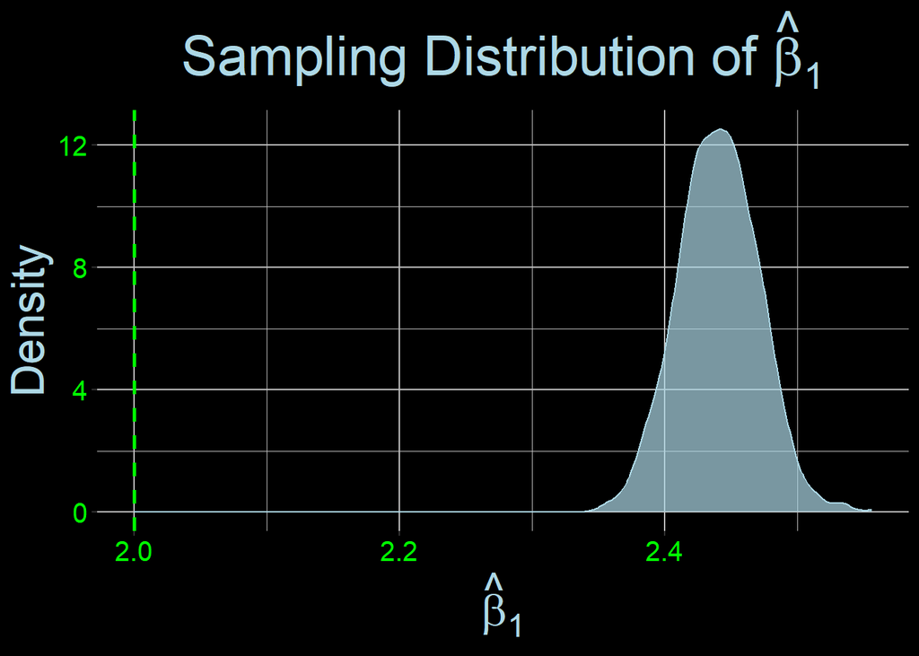

```r
# Plot the density of the slope estimates
ggplot(dt_estimates, aes(x = beta_hat_1)) +
  geom_density(color = color_2, fill = color_2, alpha = 0.7) +
  geom_vline(xintercept = beta_1, color = color_1, linetype = "dashed", size = 1) +
  labs(title = expression(paste("Sampling Distribution of ", hat(beta)[1]))) +
  theme(
    panel.background = element_rect(fill = "black", color = "black"),
    plot.background = element_rect(fill = "black", color = "black"),
    panel.grid.major = element_line(color = "gray"),
    panel.grid.minor = element_line(color = "gray"),
    axis.text = element_text(color = color_1, size = 15),
    axis.title = element_text(color = color_2, size = 25),
    plot.title = element_text(hjust = 0.5, color = color_2, size = 30, face = "bold")
  ) +
  xlab(expression(hat(beta)[1])) +
  ylab("Density")
```

Indeed, the sampling distribuiton of $\widehat{\beta}_1$ is centered to the right of the parameter it is estimating ($\beta_1 = 2$) implying the estimator is biased upward.

## Downward Bias

The true underlying model is $y_i = \beta_0 + \beta_1 x_{i1} + \beta_2 x_{i2} + u_i = 1 + 2 x_{1i} + 3x_{2i} + u_i$, but suppose we don’t include $x_2$ (perhaps we don’t have data on it which is often an issue when doing empirical work). We know $x_2$ is positively related to $y$ as indicated by its positive coefficient in the model $\left(\beta_2 = 3 \right)$. Moreover, suppose $x_{1i} = \widetilde{\beta}_0 + \widetilde{\beta}_1 x_{2i} + v_i = 4 - 5 x_{2i} + v_i$ so $x_{2}$ is also negatively related to $x_1$ as indicated by its negative coefficient in the model $\left(\widetilde{\beta}_1 = -5 \right)$. Consequently, $x_2$ is positively related with $y$ and inversely related with $x_1$ meaning when we estimate the model $y_i = \beta_0 + \beta_1 x_{i1} + w_i$, $\beta_1$ should be underestimated (think positive times negative gives negative bias). Let’s verify this by generating $s = 1000$ samples each with $n = 200$ data points, run the regression of $y$ on $x_1$ using each sample, and plot the sampling distribution of $\widehat{\beta}_1$. If we are correct, then the sampling distribution should be centered around some value to the left of $\beta_1 = 2$ because $\widehat{\beta}_1$ is underestimating this parameter.

```r
# Number of samples
s <- 1000

# Number of data points to generate per sample
n <- 200

# Create a data table with empty values to store the estimates of beta_hat_1
dt_estimates <- data.table(beta_hat_1 = rep(NA, s))

# Intercept term when y is the outcome
beta_0 <- 1

# Coefficient on x_1 when y is the outcome
beta_1 <- 2

# Coefficient on x_2 when y is the outcome
beta_2 <- 3

# Intercept term when x_1 is the outcome
beta_tilde_0 <- 4

# Coefficient on x_2 when x_1 is the outcome
beta_tilde_1 <- 5

# We want to create i = 1, 2, ..., s samples
for (i in 1:s)
{

  # Error term when y is the outcome
  u <- rnorm(n, mean = 0, sd = 2)

  # Error term when x_1 is the outcome
  v <- rnorm(n, mean = 0, sd = 3)

  # x_2
  x_2 <- rnorm(n, mean = 0, sd = 1)

  # x_1
  x_1 <- beta_tilde_0 - beta_tilde_1 * x_2 + v

  # Outcome
  y <- beta_0 + beta_1 * x_1 + beta_2 * x_2 + u

  # Create a data table
  dt <- data.table(y = y, x_1 = x_1, x_2 = x_2)

  # Run regression of y on x_1
  reg <- lm(y ~ x_1, data = dt)

  # Place the current slope estimate in dt_estimates
  dt_estimates$beta_hat_1[i] <- reg$coefficients["x_1"]
}
```

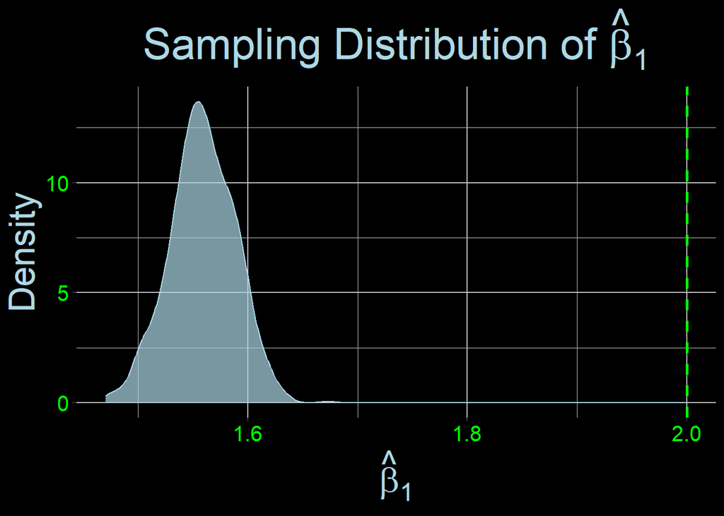

```r
# Plot the density of the slope estimates
ggplot(dt_estimates, aes(x = beta_hat_1)) +
  geom_density(color = color_2, fill = color_2, alpha = 0.7) +
  geom_vline(xintercept = beta_1, color = color_1, linetype = "dashed", size = 1) +
  labs(title = expression(paste("Sampling Distribution of ", hat(beta)[1]))) +
  theme(
    panel.background = element_rect(fill = "black", color = "black"),
    plot.background = element_rect(fill = "black", color = "black"),
    panel.grid.major = element_line(color = "gray"),
    panel.grid.minor = element_line(color = "gray"),
    axis.text = element_text(color = color_1, size = 15),
    axis.title = element_text(color = color_2, size = 25),
    plot.title = element_text(hjust = 0.5, color = color_2, size = 30, face = "bold")
  ) +
  xlab(expression(hat(beta)[1])) +
  ylab("Density")
```

Indeed, the sampling distribuiton of $\widehat{\beta}_1$ is centered to the left of the parameter it is estimating ($\beta_1 = 2$) implying the estimator is biased downward.